# PacDev Case

Maniteja Kurukunda

11/6/2022

## Q1

```r
library(tidyverse)
```

```r
library("ggplot2")
pd <- read_csv("pacdev_data.csv",show_col_types = FALSE)

summary(lm(price~sqft,data = pd))
```

```
##
## Call:
## lm(formula = price ~ sqft, data = pd)
##
## Residuals:
##     Min      1Q  Median      3Q     Max
## -622948 -151283   -1650  138951  804553
##
## Coefficients:
##              Estimate Std. Error t value Pr(>|t|)
## (Intercept) 40623.019  15862.454   2.561   0.0105 *
## sqft          269.345      7.742  34.791   <2e-16 ***
## ---
## Signif. codes:  0 '***' 0.001 '**' 0.01 '*' 0.05 '.' 0.1 ' ' 1
##
## Residual standard error: 210300 on 4989 degrees of freedom
## Multiple R-squared:  0.1953, Adjusted R-squared:  0.1951
## F-statistic:  1210 on 1 and 4989 DF,  p-value: < 2.2e-16
```

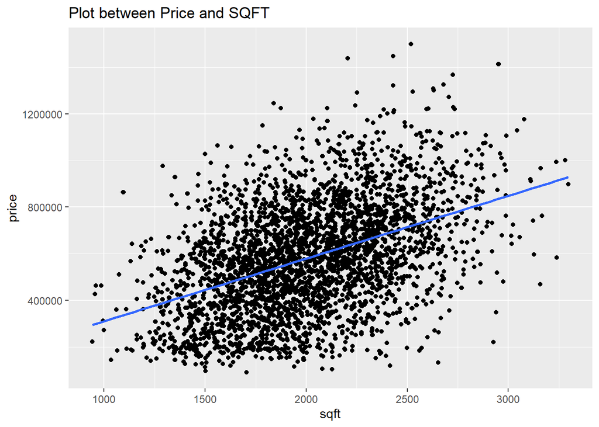

```r
ggplot(pd,aes(sqft,price))+geom_jitter()+geom_smooth(formula = y~ x,method = 'lm',se = F)+labs(title = "Plot between Price and SQFT")
```

> price=40623.019+269.345*sqft.This summary regression line shows the positive correlation between price and sqft; if sqft increases, the price of the home increases.

## Q2

```r
pd<-pd%>%mutate(centered_sqft=(sqft-mean(sqft)))
summary(lm(price~centered_sqft+city+pool+garage+bed+bath,data = pd))
```

```
##
## Call:
## lm(formula = price ~ centered_sqft + city + pool + garage + bed +
##     bath, data = pd)
##
## Residuals:
##     Min      1Q  Median      3Q     Max
## -539286 -137407   -3532  124838  852187
##
## Coefficients:
##                    Estimate Std. Error t value Pr(>|t|)
## (Intercept)      528103.213   9291.990  56.834   <2e-16 ***
## centered_sqft       271.561      7.515  36.138   <2e-16 ***
## citySanta Monica 190239.704   6757.751  28.151   <2e-16 ***
## cityWestwood      88020.719   6794.984  12.954   <2e-16 ***
## poolyes           10124.630   6760.090   1.498   0.1343
## garageyes        -14195.911   6120.799  -2.319   0.0204 *
## bed                  41.553   8420.185   0.005   0.9961
## bath              -3092.909   9439.900  -0.328   0.7432
## ---
## Signif. codes:  0 '***' 0.001 '**' 0.01 '*' 0.05 '.' 0.1 ' ' 1
##
## Residual standard error: 195000 on 4983 degrees of freedom
## Multiple R-squared:  0.3085, Adjusted R-squared:  0.3075
## F-statistic: 317.6 on 7 and 4983 DF,  p-value: < 2.2e-16
```

> price=528103.213+271.561 * centered_sqft +190239.704 * city Santa Monica +88020.719 * cityWestwood +10124.630 * pool yes -14195.911 * garages + 41.553 * bed -3092.909 * bath. From this summary multiple linear regression line Intercept of the model is 528103.213 which is positive. 1)slope for the centered sqft is 271.561. 2)slopes for each individual cities are 190239.704(Santa Monica), 88020.719(cityWestwood). Slopes are positive means price increases with the unit change in below variables Santa Monica city has the higher slope value when compare to other cities(Westwood and Long Beach).

## Q3

```r
Int_Model<-summary(lm(price~centered_sqft*city+pool+garage+bed+bath,data = pd))
Int_Model
```

```
##
## Call:
## lm(formula = price ~ centered_sqft * city + pool + garage + bed +
##     bath, data = pd)
##
## Residuals:
##     Min      1Q  Median      3Q     Max
## -536726 -138828   -2505  124312  868332
##
## Coefficients:
##                                 Estimate Std. Error t value Pr(>|t|)
## (Intercept)                    527445.45    9270.43  56.895  < 2e-16 ***
## centered_sqft                     240.63      10.14  23.726  < 2e-16 ***
## citySanta Monica               189904.29    6741.32  28.170  < 2e-16 ***
## cityWestwood                    88037.11    6778.98  12.987  < 2e-16 ***
## poolyes                         10817.17    6744.71   1.604   0.1088
## garageyes                      -14205.98    6108.49  -2.326   0.0201 *
## bed                               235.26    8403.39   0.028   0.9777
## bath                            -3099.26    9419.64  -0.329   0.7422
## centered_sqft:citySanta Monica     90.09      17.49   5.152 2.68e-07 ***
## centered_sqft:cityWestwood         37.95      18.05   2.103   0.0356 *
## ---
## Signif. codes:  0 '***' 0.001 '**' 0.01 '*' 0.05 '.' 0.1 ' ' 1
##
## Residual standard error: 194500 on 4981 degrees of freedom
## Multiple R-squared:  0.3122, Adjusted R-squared:  0.311
## F-statistic: 251.2 on 9 and 4981 DF,  p-value: < 2.2e-16
```

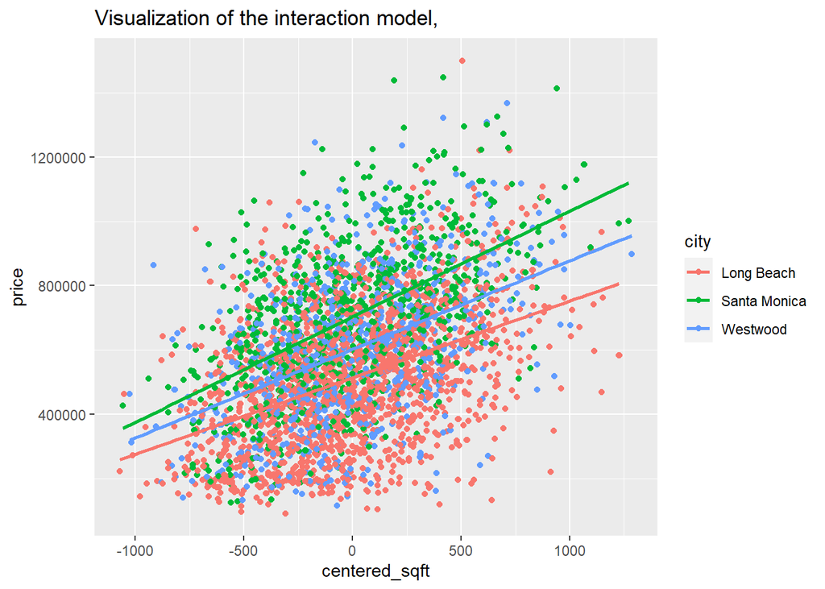

```r
ggplot(pd,aes(centered_sqft,price,col=city))+geom_jitter()+geom_smooth(formula=y~x,method = 'lm',se=FALSE)+labs(title = "Visualization of the interaction model,")
```

> From the above interaction model we can observe that Intercept of the interaction model is 527445.45 which is positive. Main effects: 1)slope for the centered sqft is 240.63. 2)slopes for each individual cities are 189904.29(Santa Monica), 88037.11(cityWestwood). Slopes are positive means price increases with the unit change in the variables. Interaction effects: 1)centered_sqft:citySanta Monica = 90.09. 2)centered_sqft:cityWestwood = 37.95. The interaction coefficients are positive which means price increase with the below interactions. we can clear observe that sant monica city interaction with sqft has higher interaction effect when compare to other cities combination with sqft.

## Q4

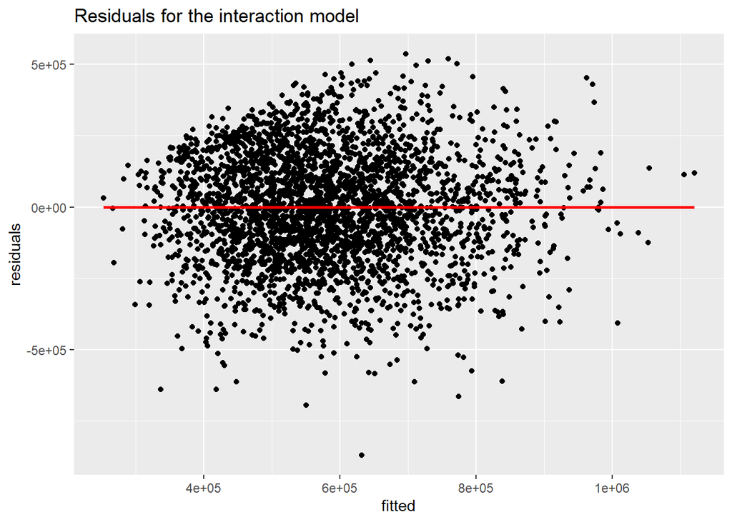

```r
plot1<-pd %>%
  mutate(fitted = fitted(lm(price~centered_sqft*city+pool+garage+bed+bath,data = pd)),
         residuals = fitted-price) %>%
  ggplot(aes(fitted, residuals)) +
  geom_point() +
  geom_smooth(formula=y~x,method = "lm", se = F, col = "red") +
  labs(title = "Residuals for the interaction model")
plot1
```

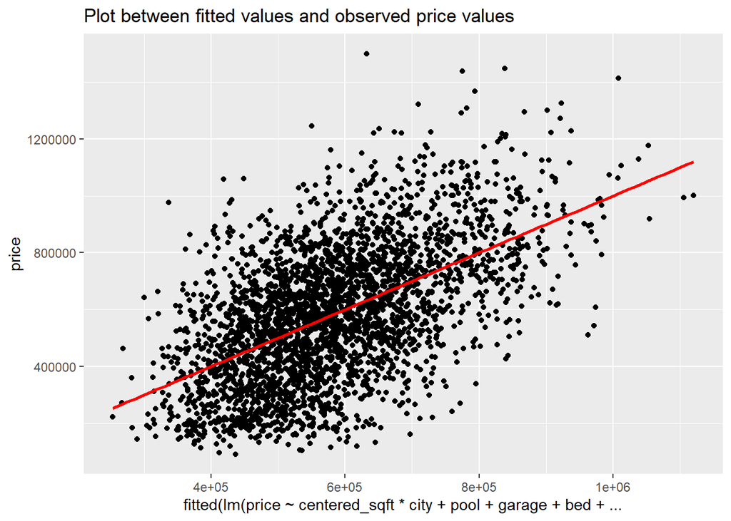

```r
plot2<-
  ggplot(pd,aes(fitted(lm(price~centered_sqft*city+pool+garage+bed+bath,data = pd)),price)) +
  geom_point() +
  geom_smooth(formula=y~x,method = "lm", se = F, col = "red")+
  labs(title = "Plot between fitted values and observed price values")
plot2
```

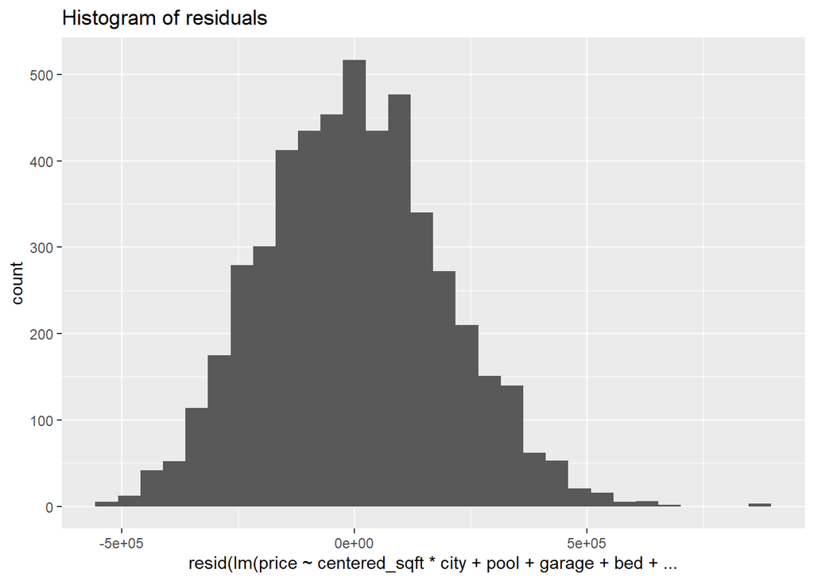

```r
plot3<-ggplot(pd,aes(resid(lm(price~centered_sqft*city+pool+garage+bed+bath,data = pd))))+geom_histogram(bins = 30)+
labs(title = "Histogram of residuals")
plot3
```

> From the above plots, we can conclude that the model is good for the following reasons. 1)Plot1 is showing the residual plot. The points are scattered randomly around the residual=0 line, which means there are no patterns in the plot, satisfying the condition of a good model. we can also conclude that a linear model is appropriate for modeling this data. 2)Plot2 is showing the linearity condition. That is, the data is linear and well described with a line that does not violate the requirements of a good model. 3)Plot3 is visualizes the histogram. The Histogram of the Residual can be used to check whether the variance is normally distributed. A symmetric bell-shaped histogram that is evenly distributed around zero indicates that the normality assumption is likely to be true, which satisfies the conditions of a good model.